# FamInsureCo_OLS_Case_Study_Student_Facing_051222

## **Welcome to the FamInsureCo Python Case Study!**

While working on the Statistics unit, you used Microsoft Excel's data analytics capabilities to analyze FamInsureCo's Data

You might have realised that whilst Excel is powerful, it was a bit tricky creating Box Plots, multiple line plots and in general, doing quick analysis in Excel. You had to use a lot of filters to subset the data, which, then provided your charts were linked, created a number of issues with your other visuals.

In this Case Study, we're going to *revisit* the FamInsureCo Case Study, but with a few added questions that will really emphasise how Python can speed up our analysis and improve our data visualisation capabilities!

**Please note that this case study is composed of two parts** — once you have completed part 1, which involves descriptive statistics, please submit your work and discuss it with your mentor before moving on to part 2.

Let's get started!

## **Descriptive Statistics**

### Step 1: Import Libraries

Import the libraries you'll need for your analysis. You will need the following libraries:

**Matplotlib** - This is Python's basic plotting library. You'll use the pyplot and dates function collections from matplotlib throughout this case study so we encourage you to important these two specific libraries with their own aliases.

**Seaborn** - This library will enable you to create aesthetically pleasing plots.

**Pandas** - This library will enable you to view and manipulate your data in a tabular format.

**statsmodels.api** - This library will enable you to create statistical models. You will need this library when performing regession analysis in Part 2 of this case study.

Please note we've included the `mpl.rcParams['figure'figsize']` code for you.

This code controls how big your charts will be with the syntax of (X,Y) where X represents the X Axis and Y, the Y Axis.

## **Place your code here**

```python
import matplotlib as mpl
import numpy as np
import matplotlib.pyplot as plt
%matplotlib inline
import seaborn as sns
import pandas as pd
import statsmodels.api as sm
sns.set_style("darkgrid")
mpl.rcParams['figure.figsize'] = (20,5)
```

### Step 2: Descriptive Statistics

The data you'll need to complete the FamInsureCo Case Study is stored in the `.csv` file titled; `FamInsureCo.csv`.

**Please complete the following below:**

i. Import the `FamInsureCo.csv` dataset and store this in a dataframe titled, `FamInsureCo_Data`.

ii. Referencing the `FamInsureCo_Data dataframe` you created, use the `.describe()` method to print out the Summary Statistics for the dataframe.

What do you observe?

## **Place your code here**

```python
FamInsureCo_Data = pd.read_csv('/Users/mythili/Downloads/Student Facing/faminsureco.csv')
FamInsureCo_Data.describe()
```

|  | age | bmi | medical_insurance_charges |
| --- | --- | --- | --- |
| count | 1338.000000 | 1338.000000 | 1338.000000 |
| mean | 39.207025 | 30.663397 | 13270.422414 |
| std | 14.049960 | 6.098187 | 12110.011240 |
| min | 18.000000 | 15.960000 | 1121.870000 |
| 25% | 27.000000 | 26.296250 | 4740.287500 |
| 50% | 39.000000 | 30.400000 | 9382.030000 |
| 75% | 51.000000 | 34.693750 | 16639.915000 |
| max | 64.000000 | 53.130000 | 63770.430000 |

### Step 3: Create a Single Scatter Plot

Previously, when we kicked off our analysis in Excel, we started with some Scatter Plots.

As a quick refresher, scatter plots are a useful way to compare two variables and determining whether any relationship might exist between them. We've included an example below of what this looks like to jog your memory.

[figure not shown]

i) Create a Scatter Plot highlighting the Medical Insurance Costs (Y-Axis) against the Body mass Index (X-Axis) using the `FamInsureCo` dataframe you created earlier.

**Hint: You might find [this](https://seaborn.pydata.org/generated/seaborn.scatterplot.html) link helpful!**

## **Place your code here**

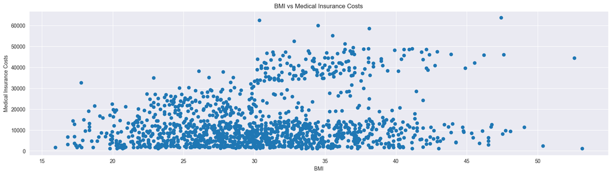

```python
bmi = FamInsureCo_Data['bmi']
medical_insurance_costs = FamInsureCo_Data['medical_insurance_charges']
plt.scatter(bmi, medical_insurance_costs)
plt.xlabel('BMI')
plt.ylabel('Medical Insurance Costs')
plt.title('BMI vs Medical Insurance Costs')
plt.show()
```

### Step 4: Multiple Classifications in a Scatter Plot

Previously, you would have recalled how you had to create a 'hacky' workaround to get multiple colors displaying for the BMI vs Medical Charges vs. Weight Classification Scatter Plot.

Now this is one of the challenges with Excel; if you want to color code your chart based off textual information, you're going to have to **manually** identify each range that applies for said textual category, and then input this in your Excel Chart.

In the next question, we're going to simplify this process dramatically through the Power of Python.

You'll tackle this question over two small steps.

i) Create a new column titled `BMI_Classification` that makes use of `IF THEN Logic` to match the below criteria:

```
A) BMI < 18.5: Underweight
B) BMI > 18.5 and <= 24.9: Healthy
C) BMI > 24.9 and <= 29.9: Slightly Overweight
D) BMI > 30: Overweight
```

**Hint: This [resource](https://blog.hubspot.com/website/pandas-if-else) will be helpful!**

If you're still stuck, take a look at this SO link [here](https://stackoverflow.com/questions/49228596/pandas-case-when-default-in-pandas)!

2. Upon completion of this logic, create a Scatter Plot that uses the `BMI_Classification` Column as the `hue` for your Scatter Plot.

We've included an example below to show-case how this syntax works:

```
seaborn.scatterplot(data=dataframe, x=dataframe['ColA'], y=dataframe['ColB'],
hue=Textual_Criteria)

plt.show()
```

## **Place your code here**

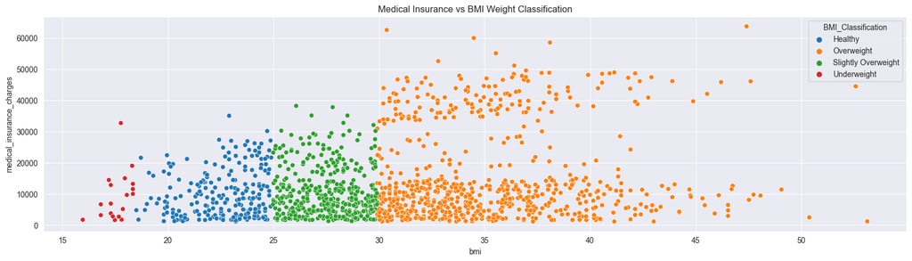

```python
def bmi_classification(bmi):
  """Returns a BMI classification based on the given BMI value."""
  if bmi < 18.5:
    return "Underweight"
  elif 18.5 <= bmi <= 24.9:
    return "Healthy"
  elif 24.9 <= bmi <= 29.9:
    return "Slightly Overweight"
  else:
    return "Overweight"

# Create a new column in the DataFrame called 'BMI_Classification'
FamInsureCo_Data["BMI_Classification"] = FamInsureCo_Data["bmi"].apply(bmi_classification)

bmi_class = FamInsureCo_Data['BMI_Classification']

sns.scatterplot(data=FamInsureCo_Data, x=bmi, y=medical_insurance_costs, hue=bmi_class)
plt.title("Medical Insurance vs BMI Weight Classification")
plt.show()
```

### Step 5: Segmentation by Smoker Status

Now we may recall that we happened to see a particularly interesting observation when we filtered our data on `smoking status`. We saw costs uptick for a certain subset of our population - namely our Smokers.

As you work through Python, it's important you understand how to `subset` your pandas dataframes. You've covered this in the datacamp material previously (Manipulating Dataframes with Pandas).

We'll have you implement the knowledge you've learned in the below questions! If you're stuck, take a look at our Syntax refresher below:

```
conditionA = dataframe['ColOfInterest'] == 'SomeString'
#This means that conditionA is going to return a list of True and False entries, where True matches the textual string, 'SomeString'

Next, we need to subset the dataframe to include only the 'SomeString' Values.
dataframe[conditionA]
That's it!
```

Create two scatter plots:

A) Where the `Smoker Status = yes`, create a Scatter Plot color coded by Smoker Status (hue), with BMI on the X-Axis and Medical Charges on the Y-Axis.

B) Where the `Smoker Status = yes`, create a Scatter Plot color coded by Smoker Status (hue), with BMI on the X-Axis and Medical Charges on the Y-Axis.

## **Place your code here**

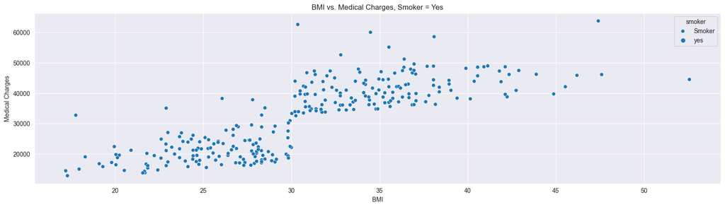

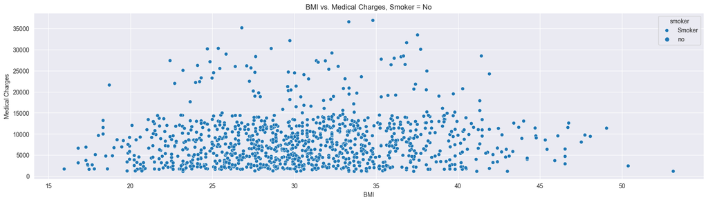

```python
# Create boolean variables for smoker status
smoker_yes = FamInsureCo_Data['smoker'] == 'yes'

# Create a scatter plot for smokers
sns.scatterplot(
    data=FamInsureCo_Data[smoker_yes],
    x="bmi",
    y="medical_insurance_charges",
    hue="smoker",
    label="Smoker"
)

# Add labels to the x and y axes
plt.xlabel("BMI")
plt.ylabel("Medical Charges")

# Add a title to the plot
plt.title("BMI vs. Medical Charges, Smoker = Yes")

# Show the plot
plt.show()

# Create boolean variables for smoker status
smoker_no = FamInsureCo_Data['smoker'] == 'no'

# Create a scatter plot for smokers
sns.scatterplot(
    data=FamInsureCo_Data[smoker_no],
    x="bmi",
    y="medical_insurance_charges",
    hue="smoker",
    label="Smoker"
)

# Add labels to the x and y axes
plt.xlabel("BMI")
plt.ylabel("Medical Charges")

# Add a title to the plot
plt.title("BMI vs. Medical Charges, Smoker = No")

# Show the plot
plt.show()
```

**What do you observe across all the visualisations?**

Smokers has more charges, compared to the non-smokers. Especially for the people with BMI greater than 30.

### Step 6: Box Plots

Now you might recall that we had created some Box Plot visualisations in Excel. These were a little frustrating due to the filters in Excel that would impact your linked charts.

Thankfully, Python, and subsequently, `seaborn` make creating box plots much easier.

We've included an example of the syntax you'll need to recall over [here](https://seaborn.pydata.org/generated/seaborn.boxplot.html).

Please create:

**i) A Box Plot showcasing the spread of Medical Insurance Costs versus Region with the hue set to Smoker Column.**

## **Place your code here**

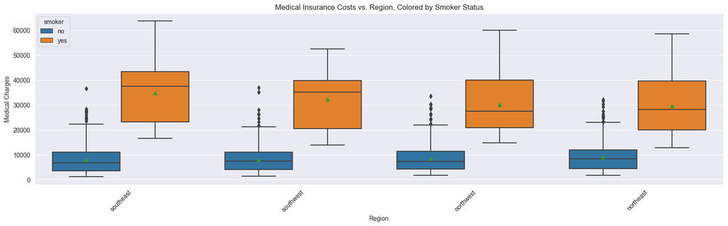

```python
sns.boxplot(
    x = "region",
    y = "medical_insurance_charges",
    hue = "smoker",
    showmeans=True,
    data=FamInsureCo_Data
)

# Rotate the x labels to prevent overlapping
plt.xticks(rotation=45)

# Add labels to the x and y axes
plt.xlabel("Region")
plt.ylabel("Medical Charges")

# Add a title to the plot
plt.title("Medical Insurance Costs vs. Region, Colored by Smoker Status")

# Show the plot
plt.show()
```

### Step 7: Visualisations by Age

Now it's important that we're able to effectively visualise our population and the respective age profiles.

Could there be an apparent relationship between an individuals age profile and their medical charges?

We might assume yes, but let's visualise this with some histograms!

Below is an example of a Histogram, segmented by penguin species. 🐧

[figure not shown]

We won't be segmenting our data by 🐧, but rather, by Age Profile!

i) Create a new column, `Age Classification` in your `FamInsureCo` dataframe using the `age` column, that classifies the data into the following criteria:

```
0 - 18 = Youth (Note; This is not inclusive of 18 in this range)
18 - 25 = Young Adult
25 - 35 = Adult
35 - 60 = Mature Age Adult
>=60	Senior
```

**Hint: You'll do the same thing you did in Step 4! Look back at this [resource](https://blog.hubspot.com/website/pandas-if-else) if you're stuck!**

ii) Upon completion of this, create 5 Histograms , one for each of the different `Age Classifications` where the X argument is set to `medical_insurance_charges`

## **Place your code here**

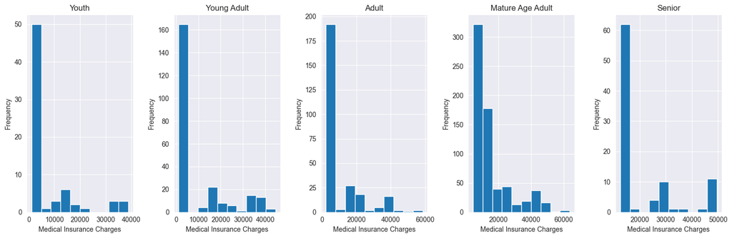

```python
# Create a new column called 'Age Classification'
FamInsureCo_Data['Age Classification'] = pd.cut(
    FamInsureCo_Data['age'],
    bins=[0, 18, 25, 35, 60, float('inf')],
    labels=['Youth', 'Young Adult', 'Adult', 'Mature Age Adult', 'Senior']
)

# Get the number of age classifications
num_age_classifications = len(FamInsureCo_Data['Age Classification'].unique())

# Create a figure with 5 subplots
fig, axes = plt.subplots(nrows=1, ncols=num_age_classifications, figsize=(15, 5))

# Iterate over the age classifications and plot a histogram for each one
for i, age_classification in enumerate(FamInsureCo_Data['Age Classification'].unique()):
    ax = axes[i]
    FamInsureCo_Data[FamInsureCo_Data['Age Classification'] == age_classification]['medical_insurance_charges'].hist(ax=ax)
    ax.set_title(age_classification)
    ax.set_xlabel('Medical Insurance Charges')
    ax.set_ylabel('Frequency')

# Tighten the layout of the subplots
plt.tight_layout()

# Show the plot
plt.show()
```

**What do you observe across all the visualisations?**

iii) Now we know that our Histogram might appear a bit misleading as we haven't accounted for the smoker status profile.

**Filter the FamInsureCo Dataframe by Smoking Status and create two sets of histograms, one where the smoker status = yes, and one where the Smoking Status = No.**

Do we observe any differences?

## **Place your code here for where the Smoker = Yes**

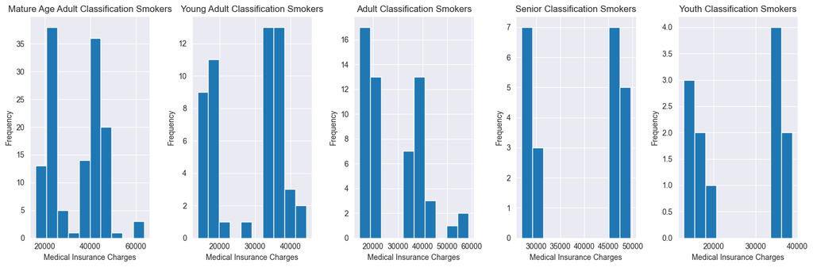

```python
smokers = FamInsureCo_Data[FamInsureCo_Data['smoker'] == 'yes']

# Get the number of age classifications
num_age_classifications = len(smokers['Age Classification'].unique())

# Create a figure with num_age_classifications subplots
fig, axes = plt.subplots(nrows=1, ncols=num_age_classifications, figsize=(15, 5))

# Iterate over the age classifications and plot a histogram for each one
for i, age_classification in enumerate(smokers['Age Classification'].unique()):
    ax = axes[i]
    smokers[smokers['Age Classification'] == age_classification]['medical_insurance_charges'].hist(ax=ax)
    ax.set_title('{} {} {}'.format(age_classification, 'Classification', 'Smokers'))
    ax.set_xlabel('Medical Insurance Charges')
    ax.set_ylabel('Frequency')

# Tighten the layout of the subplots
plt.tight_layout()

# Show the plot
plt.show()
```

**What do you observe across all the visualisations?**

## **Place your code here for where the Smoker = No**

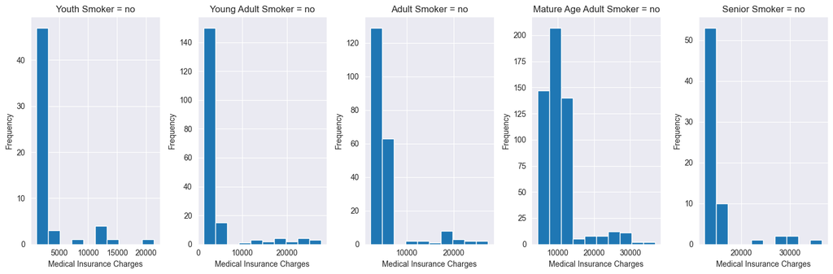

```python
non_smokers = FamInsureCo_Data[FamInsureCo_Data['smoker'] == 'no']

# Get the number of age classifications
num_age_classifications = len(non_smokers['Age Classification'].unique())

# Create a figure with num_age_classifications subplots
fig, axes = plt.subplots(nrows=1, ncols=num_age_classifications, figsize=(15, 5))

# Iterate over the age classifications and plot a histogram for each one
for i, age_classification in enumerate(non_smokers['Age Classification'].unique()):
    ax = axes[i]
    non_smokers[non_smokers['Age Classification'] == age_classification]['medical_insurance_charges'].hist(ax=ax)
    ax.set_title('{} Smoker = no'.format(age_classification))
    ax.set_xlabel('Medical Insurance Charges')
    ax.set_ylabel('Frequency')

# Tighten the layout of the subplots
plt.tight_layout()

# Show the plot
plt.show()
```

**What do you observe across all the visualisations?**

Non smokers medical insurance is mostly less than 10k.

### Step 8: Segmentation by Gender (Sex)

Now we know that there appears to be a Hypotheses that one of the two sexes, may have higher medical insurance costs.

However, we know that this isn't isolated only to gender.

Smoking Status obviously has a larger role to play here

**Create a Box Plot where the `hue` is set to `smoker` with the X-Axis set to Gender (`i.e. sex`). What do you observe?**

## **Place your code here**

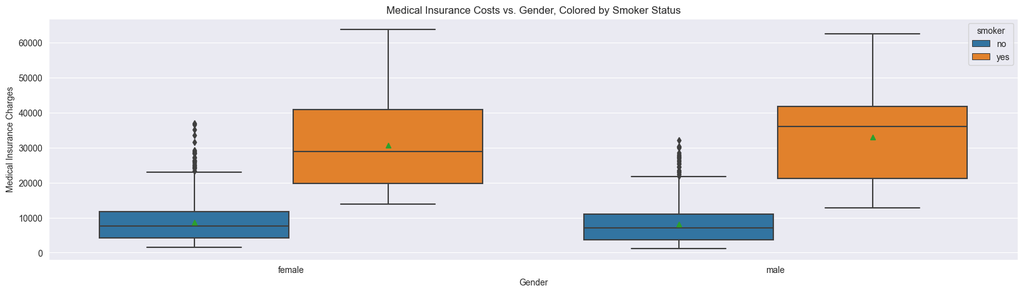

```python
# Create a box plot of medical insurance costs versus sex, colored by smoker status
sns.boxplot(
    x = "sex",
    y = "medical_insurance_charges",
    hue = "smoker",
    showmeans=True,
    data=FamInsureCo_Data
)

# Rotate the x labels to prevent overlapping
plt.xticks(rotation=0)

# Add labels to the x and y axes
plt.xlabel("Gender")
plt.ylabel("Medical Insurance Charges")

# Add a title to the plot
plt.title("Medical Insurance Costs vs. Gender, Colored by Smoker Status")

# Show the plot
plt.show()
```

**What do you observe across all the visualisations?**

### Please note that Step 9 and 10 are Challenge Questions and will intentionally be more difficult

### Step 9: Create Quartiles

Now we haven't done any particular treatments to our data analysis. In our case, we might have **Outliers** in our Medical Insurance Charges that can skew our dataset.

We're going to be looking at fitting a `regression model` later in our Inferential Statistics Analysis, but before that, it's important we treat our data and ensure we remove our Outliers. Take a look at the image below; you should be able to clearly identify the data point that is different from the rest.

If you were to take the average including that data point, the average would be inflated, when in fact that data point isn't representative of the series. Generally, we would remove Outliers to ensure we have a representative population mean, or, use the median.

Now let's see what happens if we are to remove our Outliers.

[figure not shown]

To do this, we'll have you perform the below:

Create two new variables called `Q1 and Q3` using the `FamInsureCo` Dataframe, focusing specifically on the **medical insurance charges** column.

**i) Q1 should contain the 25th percentile for all columns in the dataframe while Q3 should contain the 75th percentile for all the columns in the dataframe.**

You may want to use the .quantile() function explained [here](https://www.geeksforgeeks.org/python-pandas-dataframe-quantile/)

**ii) After defining Q1 and Q3, calculate the interquartile range **(IQR = Q3 - Q1)** for all columns in the dataframe and print it to the screen.**

## **Place your code here**

```python
# Calculate the 25th and 75th percentiles for all columns in the dataframe
Q1 = FamInsureCo_Data['medical_insurance_charges'].quantile(0.25)
Q3 = FamInsureCo_Data['medical_insurance_charges'].quantile(0.75)

IQR = Q3 - Q1

# Print the interquartile range to the screen
print(IQR)
```

```
11899.6275
```

The general logic for removing an outliers is:

**Any Value that is either Q1 - 1.5x IQR or greater than Q3 + 1.5x IQR is considered an outlier.**

Where Q1 = Quartile 1 and Q3 = Quartile 3

Let's break these down to a few simple steps and tackle how to calculate this.

1. Define the Quartiles Q1 and Q3.
2. Calculate the Interquartile Range (Q3 - Q1)
3. Create two new variables; Lower_Range (Q1 - 1.5x IQR) and Upper_Range ( Q3 + 1.5x IQR).
4. Using Boolean Subsetting, filter the Dataframe for Outliers and remove them
5. Calculate what the proportion of Outliers exist (i.e. Number of entries left after Outlier removal / Number of total entries in dataset)

### Step 10: Identify & Remove Outliers

Continuing in from Step 9 - we still need to calculate **how** we can remove our outliers.

We're aware of the overall formula as shown per below.

**Outlier = Q1 - 1.5x IQR OR Q3 + 1.5x IQR**

Now let's work out how we can identify these Outliers step by step.

**i) Define two new variables, Lower_Limit and Upper_Limit can be calculated as:**

Lower_Limit = Q1 - 1.5 * IQR

Upper_Limit = Q3 + 1.5 * IQR

**ii) Using Lower_Limit and Upper_Limit with an OR (|) condition, filter the dataframe to include *only* the Outliers. How many Outliers do we have?**

**Now note that we only want to use the *upper limit* for our filtering. This is because the lower limit has us retrieve -ve medical insurance charges, which isn't valid.**

What this means is that the syntax should look like this:

```
FamInsureCoOutliers = some_dataframe [ (some_dataframe > Upper_Limit)]
```

If you're stuck, [here's](https://stackoverflow.com/questions/54398554/how-to-remove-outliers-in-python) a link that will show you how you can remove Outliers in Python!

**iii) What is the percentage of data that remains after we've removed the Outliers from the `FamInsureCo` dataset?**

## **Place your code here**

```python
# Define the Lower_Limit and Upper_Limit variables
Lower_Limit = FamInsureCo_Data['medical_insurance_charges'].quantile(0.25) - 1.5 * IQR
Upper_Limit = FamInsureCo_Data['medical_insurance_charges'].quantile(0.75) + 1.5 * IQR

# Filter the dataframe to include only the outliers
FamInsureCoOutliers = FamInsureCo_Data[FamInsureCo_Data['medical_insurance_charges'] > Upper_Limit]

# Count the number of outliers
num_outliers = FamInsureCoOutliers.shape[0]

# Print the number of outliers to the screen
print('Number of outliers:', num_outliers)

# Calculate the percentage of data that remains after removing the outliers
percentage_remaining = (FamInsureCo_Data.shape[0] - num_outliers) / FamInsureCo_Data.shape[0] * 100

# Print the percentage of data that remains to the screen
print('Percentage of data remaining:', percentage_remaining)
```

```
Number of outliers: 139
Percentage of data remaining: 89.61136023916293
```

**Now that you've removed the Outliers and discovered you still have a significant amount of data left - do you think removing Outliers is problematic or not? Please state your answer below and explain what your thoughts are.**

If there are so many outliers, it can impact our analysis

## Part II: Inferential Statistical Analysis

When you performed inferential statistics for FamInsureCo using Excel, you made use of the `corr` function as well as the data analysis package to create a regression model.

You'll be revisiting these functions but using Python to do so.

Specifically, you'll be using a *heatmap* via the `seaborn` library, which will help improve your ability to visualise correlations between variables.

### Step 11: Create a Heatmap

i) Using Seaborn's heatmap function, create a heatmap that clearly shows the correlations (R) for all variables using the `faminsure_co dataset`.

The syntax of Seaborn takes the following arguments:

[sns.heatmap(correlated_dataframe, annot=True)](https://seaborn.pydata.org/generated/seaborn.heatmap.html)

You'll need to ensure you use the following [.corr()](https://pandas.pydata.org/pandas-docs/stable/reference/api/pandas.DataFrame.corr.html) function and apply this to your dataframe first, **before** passing this to the sns.heatmap() function.

## **Place your code here**

#### We've included an example of what the output *may* look like below

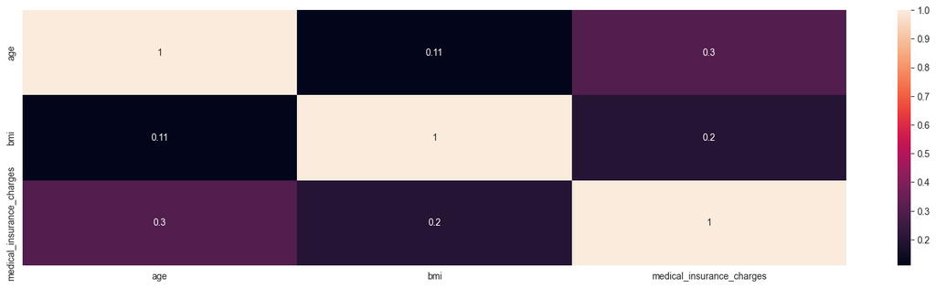

```python
sns.heatmap(FamInsureCo_Data.corr(), annot=True)
```

**Which variables seem to correlate with Medical Insurance Charges?**

You might have realised that you only have **3** variables appearing in your correlated Heatmap. This might seem strange as you would recall creating some other variables such as `age_classification` and `bmi_classification`.

Why don't they appear?

Well, the simple reason is that these variables **aren't** numerical variables, but textual. Correlations can only be performed on **numerical variables** .

This means, we'll need to convert our textual variables INTO numerical variables. We can do this using a function in pandas called `pd.get_dummies`.

Take a look at the `FamInsureCo Inf. Stats Data` tab and look at the data we've converted for you; this is what we'll be doing in the below step. We're simply converting our categorical variables into numerical variables that we can then use correlation, to unpack, and better understand how they relate to our medical insurance charges!

This is what we'll do in the below step, so let's get started!

### Step 12: Creating Dummy Variables

i) Using Pandas `pd.get_dummies()` function, convert the following variables and store this in a new dataframe called `faminsureco_converted`:

1. age_classification
2. bmi_classification
3. sex
4. smoker
5. region

The syntax of pd.get_dummies() takes the following arguments:

[pd.get_dummies(dataframe['column_or_columns_of_interest']](https://pandas.pydata.org/docs/reference/api/pandas.get_dummies.html)

**Hint: If you need some additional guidance, click on the link over [here!](https://pandas.pydata.org/docs/reference/api/pandas.get_dummies.html)**

ii) Upon completion of this, join `faminsureco` and `faminsureco_converted` into **one** new dataframe called `faminsure_combined`.

**Hint: Don't forget to think about using the `pd.concat` command you've learned about!**

iii) Having created `faminsure_combined`, re-run your correlation and visualise the corresponding Heatmap (as per Step 10).

What do you notice if you focus specifically on **medical insurance charges** ?

```python
FamInsureCo_Data.columns
```

```
Index(['age', 'sex', 'bmi', 'smoker', 'region', 'medical_insurance_charges',
       'BMI_Classification', 'Age Classification'],
      dtype='object')
```

```
Correlations with medical insurance charges:
age                                       0.299008
bmi                                       0.198341
medical_insurance_charges                 1.000000
Age Classification_Youth                 -0.119123
Age Classification_Young Adult           -0.138009
Age Classification_Adult                 -0.114735
Age Classification_Mature Age Adult       0.162347
Age Classification_Senior                 0.173898
BMI_Classification_Healthy               -0.106512
BMI_Classification_Overweight             0.196857
BMI_Classification_Slightly Overweight   -0.117768
BMI_Classification_Underweight           -0.044960
sex_female                               -0.057292
sex_male                                  0.057292
smoker_no                                -0.787251
smoker_yes                                0.787251
region_northeast                          0.006349
region_northwest                         -0.039905
region_southeast                          0.073982
region_southwest                         -0.043210
Name: medical_insurance_charges, dtype: float64
```

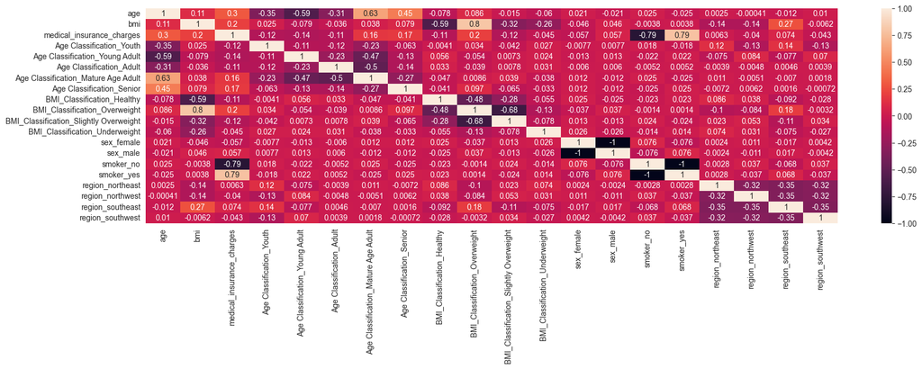

```python
# Convert categorical variables into dummy variables
faminsureco_converted = pd.get_dummies(FamInsureCo_Data[['Age Classification', 'BMI_Classification', 'sex', 'smoker', 'region']])

# Create a new dataframe with the original data and the dummy variables
faminsure_combined = pd.concat([FamInsureCo_Data, faminsureco_converted], axis=1)

# Calculate the correlation matrix
corr_matrix = faminsure_combined.corr()

# Create the heatmap using Seaborn's heatmap function
sns.heatmap(corr_matrix, annot=True)

# Focus on medical insurance charges
medical_insurance_charges_corr = corr_matrix['medical_insurance_charges']

print("Correlations with medical insurance charges:")
print(medical_insurance_charges_corr)
```

### Step 13: Create a Barplot of Correlated Features

**i) Using the correlated dataframe you've created earlier, create a barplot that shows the correlated features against Medical Insurance Charges, in descending order.**

You'll have to think carefully regarding this question.

You'd know that you can get the correlation values from the following command:

```
dataframe.corr()
```

Upon printing this out, you should get a **dataframe** that looks like the below:

```python
faminsure_combined.corr()
```

|  | age | bmi | medical_insurance_charges | Age Classification_Youth | Age Classification_Young Adult | Age Classification_Adult | Age Classification_Mature Age Adult | Age Classification_Senior | BMI_Classification_Healthy | BMI_Classification_Overweight | BMI_Classification_Slightly Overweight | BMI_Classification_Underweight | sex_female | sex_male | smoker_no | smoker_yes | region_northeast | region_northwest | region_southeast | region_southwest |
| --- | --- | --- | --- | --- | --- | --- | --- | --- | --- | --- | --- | --- | --- | --- | --- | --- | --- | --- | --- | --- |
| age | 1.000000 | 0.109272 | 0.299008 | -0.352096 | -0.585431 | -0.313855 | 0.628548 | 0.447705 | -0.078098 | 0.086397 | -0.014948 | -0.060142 | 0.020856 | -0.020856 | 0.025019 | -0.025019 | 0.002475 | -0.000407 | -0.011642 | 0.010016 |
| bmi | 0.109272 | 1.000000 | 0.198341 | 0.025352 | -0.079154 | -0.035833 | 0.038225 | 0.078810 | -0.591119 | 0.798256 | -0.324046 | -0.264664 | -0.046371 | 0.046371 | -0.003750 | 0.003750 | -0.138156 | -0.135996 | 0.270025 | -0.006205 |
| medical_insurance_charges | 0.299008 | 0.198341 | 1.000000 | -0.119123 | -0.138009 | -0.114735 | 0.162347 | 0.173898 | -0.106512 | 0.196857 | -0.117768 | -0.044960 | -0.057292 | 0.057292 | -0.787251 | 0.787251 | 0.006349 | -0.039905 | 0.073982 | -0.043210 |
| Age Classification_Youth | -0.352096 | 0.025352 | -0.119123 | 1.000000 | -0.108187 | -0.116700 | -0.234580 | -0.062991 | -0.004074 | 0.034395 | -0.041941 | 0.026976 | -0.007699 | 0.007699 | 0.017838 | -0.017838 | 0.120631 | -0.132078 | 0.138429 | -0.132078 |
| Age Classification_Young Adult | -0.585431 | -0.079154 | -0.138009 | -0.108187 | 1.000000 | -0.232197 | -0.466742 | -0.125334 | 0.056187 | -0.054263 | 0.007339 | 0.023512 | -0.012765 | 0.012765 | -0.021667 | 0.021667 | -0.074900 | 0.084146 | -0.076875 | 0.070451 |
| Age Classification_Adult | -0.313855 | -0.035833 | -0.114735 | -0.116700 | -0.232197 | 1.000000 | -0.503468 | -0.135196 | 0.032798 | -0.038991 | 0.007812 | 0.030687 | -0.005968 | 0.005968 | -0.005174 | 0.005174 | -0.003910 | -0.004778 | 0.004579 | 0.003932 |
| Age Classification_Mature Age Adult | 0.628548 | 0.038225 | 0.162347 | -0.234580 | -0.466742 | -0.503468 | 1.000000 | -0.271759 | -0.046867 | 0.008570 | 0.039327 | -0.037693 | 0.012022 | -0.012022 | 0.025259 | -0.025259 | 0.010578 | -0.005130 | -0.007014 | 0.001842 |
| Age Classification_Senior | 0.447705 | 0.078810 | 0.173898 | -0.062991 | -0.125334 | -0.135196 | -0.271759 | 1.000000 | -0.040686 | 0.097035 | -0.064807 | -0.033277 | 0.011733 | -0.011733 | -0.024752 | 0.024752 | -0.007178 | 0.006203 | 0.001625 | -0.000719 |
| BMI_Classification_Healthy | -0.078098 | -0.591119 | -0.106512 | -0.004074 | 0.056187 | 0.032798 | -0.046867 | -0.040686 | 1.000000 | -0.478526 | -0.280901 | -0.054942 | 0.024759 | -0.024759 | -0.022593 | 0.022593 | 0.085552 | 0.037836 | -0.092073 | -0.027752 |
| BMI_Classification_Overweight | 0.086397 | 0.798256 | 0.196857 | 0.034395 | -0.054263 | -0.038991 | 0.008570 | 0.097035 | -0.478526 | 1.000000 | -0.675726 | -0.132166 | -0.036727 | 0.036727 | -0.001393 | 0.001393 | -0.102774 | -0.083570 | 0.182551 | -0.003202 |
| BMI_Classification_Slightly Overweight | -0.014948 | -0.324046 | -0.117768 | -0.041941 | 0.007339 | 0.007812 | 0.039327 | -0.064807 | -0.280901 | -0.675726 | 1.000000 | -0.077583 | 0.013220 | -0.013220 | 0.023894 | -0.023894 | 0.023144 | 0.052941 | -0.105690 | 0.033617 |
| BMI_Classification_Underweight | -0.060142 | -0.264664 | -0.044960 | 0.026976 | 0.023512 | 0.030687 | -0.037693 | -0.033277 | -0.054942 | -0.132166 | -0.077583 | 1.000000 | 0.025927 | -0.025927 | -0.013803 | 0.013803 | 0.074146 | 0.030765 | -0.075306 | -0.026686 |
| sex_female | 0.020856 | -0.046371 | -0.057292 | -0.007699 | -0.012765 | -0.005968 | 0.012022 | 0.011733 | 0.024759 | -0.036727 | 0.013220 | 0.025927 | 1.000000 | -1.000000 | 0.076185 | -0.076185 | 0.002425 | 0.011156 | -0.017117 | 0.004184 |
| sex_male | -0.020856 | 0.046371 | 0.057292 | 0.007699 | 0.012765 | 0.005968 | -0.012022 | -0.011733 | -0.024759 | 0.036727 | -0.013220 | -0.025927 | -1.000000 | 1.000000 | -0.076185 | 0.076185 | -0.002425 | -0.011156 | 0.017117 | -0.004184 |
| smoker_no | 0.025019 | -0.003750 | -0.787251 | 0.017838 | -0.021667 | -0.005174 | 0.025259 | -0.024752 | -0.022593 | -0.001393 | 0.023894 | -0.013803 | 0.076185 | -0.076185 | 1.000000 | -1.000000 | -0.002811 | 0.036945 | -0.068498 | 0.036945 |
| smoker_yes | -0.025019 | 0.003750 | 0.787251 | -0.017838 | 0.021667 | 0.005174 | -0.025259 | 0.024752 | 0.022593 | 0.001393 | -0.023894 | 0.013803 | -0.076185 | 0.076185 | -1.000000 | 1.000000 | 0.002811 | -0.036945 | 0.068498 | -0.036945 |
| region_northeast | 0.002475 | -0.138156 | 0.006349 | 0.120631 | -0.074900 | -0.003910 | 0.010578 | -0.007178 | 0.085552 | -0.102774 | 0.023144 | 0.074146 | 0.002425 | -0.002425 | -0.002811 | 0.002811 | 1.000000 | -0.320177 | -0.345561 | -0.320177 |
| region_northwest | -0.000407 | -0.135996 | -0.039905 | -0.132078 | 0.084146 | -0.004778 | -0.005130 | 0.006203 | 0.037836 | -0.083570 | 0.052941 | 0.030765 | 0.011156 | -0.011156 | 0.036945 | -0.036945 | -0.320177 | 1.000000 | -0.346265 | -0.320829 |
| region_southeast | -0.011642 | 0.270025 | 0.073982 | 0.138429 | -0.076875 | 0.004579 | -0.007014 | 0.001625 | -0.092073 | 0.182551 | -0.105690 | -0.075306 | -0.017117 | 0.017117 | -0.068498 | 0.068498 | -0.345561 | -0.346265 | 1.000000 | -0.346265 |
| region_southwest | 0.010016 | -0.006205 | -0.043210 | -0.132078 | 0.070451 | 0.003932 | 0.001842 | -0.000719 | -0.027752 | -0.003202 | 0.033617 | -0.026686 | 0.004184 | -0.004184 | 0.036945 | -0.036945 | -0.320177 | -0.320829 | -0.346265 | 1.000000 |

You might think to yourself this looks **suspiciously like a dataframe with columns that you can manipulate**.

This is indeed the case.

With this hint in mind, you should be able to **select the relevant column of interest and combine this with the .plot(kind='__') function to answer the question**. Don't forget to think about .sort_values() to help sort your data!